# Shinkasen Travel Experience Prediction

**Goal:** The goal of the problem is to predict whether a passenger was satisfied or not considering his/her overall experience of traveling on the Shinkansen Bullet Train.

**Dataset:**

The problem consists of 2 separate datasets: Travel data & Survey data. Travel data has information related to passengers and attributes related to the Shinkansen train, in which they traveled. The survey data is aggregated data of surveys indicating the post-service experience. You are expected to treat both these datasets as raw data and perform any necessary data cleaning/validation steps as required.

The data has been split into two groups and provided in the Dataset folder. The folder contains both train and test data separately.

- Train_Data
- Test_Data

Target Variable: Overall_Experience (1 represents ‘satisfied’, and 0 represents ‘not satisfied’)

The training set can be used to build your machine learning model. The training set has labels for the target column - Overall_Experience.

The testing set should be used to see how well your model performs on unseen data. For the test set, it is expected to predict the ‘Overall_Experience’ level for each participant.

**Data Dictionary:**

All the data is self-explanatory. The survey levels are explained in the Data Dictionary file.

Submission File Format: You will need to submit a CSV file with exactly 35,602 entries plus a header row. The file should have exactly two columns

- ID
- Overall_Experience (contains 0 & 1 values, 1 represents ‘Satisfied’, and 0 represents ‘Not Satisfied’)

**Evaluation Criteria:**

Accuracy Score: The evaluation metric is simply the percentage of predictions made by the model that turned out to be correct. This is also called the accuracy of the model. It will be calculated as the total number of correct predictions (True Positives + True Negatives) divided by the total number of observations in the dataset.

In other words, the best possible accuracy is 100% (or 1) and the worst possible accuracy 0%

```python
from google.colab import drive
drive.mount('/content/drive')
```

```python
# This will help in making the Python code more structured automatically (good coding practice)
#% Load_ext nb_black

# Libraries to help with reading and manipulating data
import numpy as np
import pandas as pd

# Library to --- data
from sklearn.model_selection import train_test_split

# Libaries to help with data visualization
import matplotlib.pyplot as plt
import seaborn as sns

# Removes the limit for the number of displayed columns
pd.set_option("display.max_columns", None)
# Sets the limit for the number of displayed rows
pd.set_option("display.max_rows", 300)

# Import libraries for building linear regression model
from statsmodels.formula.api import ols
import statsmodels.api as sm
from sklearn.linear_model import LinearRegression

# Algorithms to use
from sklearn import tree

from sklearn.tree import DecisionTreeClassifier

from sklearn.ensemble import RandomForestClassifier

# Metrics to evaluate the model
from sklearn import metrics

from sklearn.metrics import confusion_matrix, classification_report,recall_score,precision_score, accuracy_score

# For tuning the model
from sklearn.model_selection import GridSearchCV

# To ignore warnings
import warnings
warnings.filterwarnings("ignore")

# Import library for preparing data
from sklearn.model_selection import train_test_split

import warnings
warnings.filterwarnings("ignore")
```

## Load datasets

```python
travel_train = pd.read_csv('/content/drive/MyDrive/Colab Notebooks/GL Hackathon/Traveldata_train.csv')
survey_train = pd.read_csv('/content/drive/MyDrive/Colab Notebooks/GL Hackathon/Surveydata_train.csv')
```

```python
travel_train.head()
```

|  | ID | Gender | Customer_Type | Age | Type_Travel | Travel_Class | Travel_Distance | Departure_Delay_in_Mins | Arrival_Delay_in_Mins |
| --- | --- | --- | --- | --- | --- | --- | --- | --- | --- |
| 0 | 98800001 | Female | Loyal Customer | 52.0 | NaN | Business | 272 | 0.0 | 5.0 |
| 1 | 98800002 | Male | Loyal Customer | 48.0 | Personal Travel | Eco | 2200 | 9.0 | 0.0 |
| 2 | 98800003 | Female | Loyal Customer | 43.0 | Business Travel | Business | 1061 | 77.0 | 119.0 |
| 3 | 98800004 | Female | Loyal Customer | 44.0 | Business Travel | Business | 780 | 13.0 | 18.0 |
| 4 | 98800005 | Female | Loyal Customer | 50.0 | Business Travel | Business | 1981 | 0.0 | 0.0 |

```python
survey_train.head()
```

|  | ID | Overall_Experience | Seat_Comfort | Seat_Class | Arrival_Time_Convenient | Catering | Platform_Location | Onboard_Wifi_Service | Onboard_Entertainment | Online_Support | Ease_of_Online_Booking | Onboard_Service | Legroom | Baggage_Handling | CheckIn_Service | Cleanliness | Online_Boarding |
| --- | --- | --- | --- | --- | --- | --- | --- | --- | --- | --- | --- | --- | --- | --- | --- | --- | --- |
| 0 | 98800001 | 0 | Needs Improvement | Green Car | Excellent | Excellent | Very Convenient | Good | Needs Improvement | Acceptable | Needs Improvement | Needs Improvement | Acceptable | Needs Improvement | Good | Needs Improvement | Poor |
| 1 | 98800002 | 0 | Poor | Ordinary | Excellent | Poor | Needs Improvement | Good | Poor | Good | Good | Excellent | Needs Improvement | Poor | Needs Improvement | Good | Good |
| 2 | 98800003 | 1 | Needs Improvement | Green Car | Needs Improvement | Needs Improvement | Needs Improvement | Needs Improvement | Good | Excellent | Excellent | Excellent | Excellent | Excellent | Good | Excellent | Excellent |
| 3 | 98800004 | 0 | Acceptable | Ordinary | Needs Improvement | NaN | Needs Improvement | Acceptable | Needs Improvement | Acceptable | Acceptable | Acceptable | Acceptable | Acceptable | Good | Acceptable | Acceptable |
| 4 | 98800005 | 1 | Acceptable | Ordinary | Acceptable | Acceptable | Manageable | Needs Improvement | Good | Excellent | Good | Good | Good | Good | Good | Good | Good |

```python
travel_train.info()
```

```
<class 'pandas.core.frame.DataFrame'>
RangeIndex: 94379 entries, 0 to 94378
Data columns (total 9 columns):
 #   Column                   Non-Null Count  Dtype
---  ------                   --------------  -----
 0   ID                       94379 non-null  int64
 1   Gender                   94302 non-null  object
 2   Customer_Type            85428 non-null  object
 3   Age                      94346 non-null  float64
 4   Type_Travel              85153 non-null  object
 5   Travel_Class             94379 non-null  object
 6   Travel_Distance          94379 non-null  int64
 7   Departure_Delay_in_Mins  94322 non-null  float64
 8   Arrival_Delay_in_Mins    94022 non-null  float64
dtypes: float64(3), int64(2), object(4)
memory usage: 6.5+ MB
```

```python
travel_train.shape
```

```
(94379, 9)
```

```python
survey_train.info()
```

```
<class 'pandas.core.frame.DataFrame'>
RangeIndex: 94379 entries, 0 to 94378
Data columns (total 17 columns):
 #   Column                   Non-Null Count  Dtype
---  ------                   --------------  -----
 0   ID                       94379 non-null  int64
 1   Overall_Experience       94379 non-null  int64
 2   Seat_Comfort             94318 non-null  object
 3   Seat_Class               94379 non-null  object
 4   Arrival_Time_Convenient  85449 non-null  object
 5   Catering                 85638 non-null  object
 6   Platform_Location        94349 non-null  object
 7   Onboard_Wifi_Service     94349 non-null  object
 8   Onboard_Entertainment    94361 non-null  object
 9   Online_Support           94288 non-null  object
 10  Ease_of_Online_Booking   94306 non-null  object
 11  Onboard_Service          86778 non-null  object
 12  Legroom                  94289 non-null  object
 13  Baggage_Handling         94237 non-null  object
 14  CheckIn_Service          94302 non-null  object
 15  Cleanliness              94373 non-null  object
 16  Online_Boarding          94373 non-null  object
dtypes: int64(2), object(15)
memory usage: 12.2+ MB
```

```python
survey_train.shape
```

```
(94379, 17)
```

```python
travel_train.isnull().sum()
```

```
ID                            0
Gender                       77
Customer_Type              8951
Age                          33
Type_Travel                9226
Travel_Class                  0
Travel_Distance               0
Departure_Delay_in_Mins      57
Arrival_Delay_in_Mins       357
dtype: int64
```

```python
survey_train.isnull().sum()
```

```
ID                            0
Overall_Experience            0
Seat_Comfort                 61
Seat_Class                    0
Arrival_Time_Convenient    8930
Catering                   8741
Platform_Location            30
Onboard_Wifi_Service         30
Onboard_Entertainment        18
Online_Support               91
Ease_of_Online_Booking       73
Onboard_Service            7601
Legroom                      90
Baggage_Handling            142
CheckIn_Service              77
Cleanliness                   6
Online_Boarding               6
dtype: int64
```

```python
df_train = pd.merge(travel_train, survey_train, how = 'left', on = 'ID')
df_train.head()
```

|  | ID | Gender | Customer_Type | Age | Type_Travel | Travel_Class | Travel_Distance | Departure_Delay_in_Mins | Arrival_Delay_in_Mins | Overall_Experience | Seat_Comfort | Seat_Class | Arrival_Time_Convenient | Catering | Platform_Location | Onboard_Wifi_Service | Onboard_Entertainment | Online_Support | Ease_of_Online_Booking | Onboard_Service | Legroom | Baggage_Handling | CheckIn_Service | Cleanliness | Online_Boarding |
| --- | --- | --- | --- | --- | --- | --- | --- | --- | --- | --- | --- | --- | --- | --- | --- | --- | --- | --- | --- | --- | --- | --- | --- | --- | --- |
| 0 | 98800001 | Female | Loyal Customer | 52.0 | NaN | Business | 272 | 0.0 | 5.0 | 0 | Needs Improvement | Green Car | Excellent | Excellent | Very Convenient | Good | Needs Improvement | Acceptable | Needs Improvement | Needs Improvement | Acceptable | Needs Improvement | Good | Needs Improvement | Poor |
| 1 | 98800002 | Male | Loyal Customer | 48.0 | Personal Travel | Eco | 2200 | 9.0 | 0.0 | 0 | Poor | Ordinary | Excellent | Poor | Needs Improvement | Good | Poor | Good | Good | Excellent | Needs Improvement | Poor | Needs Improvement | Good | Good |
| 2 | 98800003 | Female | Loyal Customer | 43.0 | Business Travel | Business | 1061 | 77.0 | 119.0 | 1 | Needs Improvement | Green Car | Needs Improvement | Needs Improvement | Needs Improvement | Needs Improvement | Good | Excellent | Excellent | Excellent | Excellent | Excellent | Good | Excellent | Excellent |
| 3 | 98800004 | Female | Loyal Customer | 44.0 | Business Travel | Business | 780 | 13.0 | 18.0 | 0 | Acceptable | Ordinary | Needs Improvement | NaN | Needs Improvement | Acceptable | Needs Improvement | Acceptable | Acceptable | Acceptable | Acceptable | Acceptable | Good | Acceptable | Acceptable |
| 4 | 98800005 | Female | Loyal Customer | 50.0 | Business Travel | Business | 1981 | 0.0 | 0.0 | 1 | Acceptable | Ordinary | Acceptable | Acceptable | Manageable | Needs Improvement | Good | Excellent | Good | Good | Good | Good | Good | Good | Good |

```python
df_train.set_index('ID', inplace = True)
```

```python
df_train.shape
```

```
(94379, 24)
```

```python
df_train.info()
```

```
<class 'pandas.core.frame.DataFrame'>
Int64Index: 94379 entries, 98800001 to 98894379
Data columns (total 24 columns):
 #   Column                   Non-Null Count  Dtype
---  ------                   --------------  -----
 0   Gender                   94302 non-null  object
 1   Customer_Type            85428 non-null  object
 2   Age                      94346 non-null  float64
 3   Type_Travel              85153 non-null  object
 4   Travel_Class             94379 non-null  object
 5   Travel_Distance          94379 non-null  int64
 6   Departure_Delay_in_Mins  94322 non-null  float64
 7   Arrival_Delay_in_Mins    94022 non-null  float64
 8   Overall_Experience       94379 non-null  int64
 9   Seat_Comfort             94318 non-null  object
```

[output cut: 16 more lines]

```python
df_train.isnull().sum()
```

```
Gender                       77
Customer_Type              8951
Age                          33
Type_Travel                9226
Travel_Class                  0
Travel_Distance               0
Departure_Delay_in_Mins      57
Arrival_Delay_in_Mins       357
Overall_Experience            0
Seat_Comfort                 61
Seat_Class                    0
Arrival_Time_Convenient    8930
Catering                   8741
Platform_Location            30
Onboard_Wifi_Service         30
Onboard_Entertainment        18
Online_Support               91
Ease_of_Online_Booking       73
Onboard_Service            7601
Legroom                      90
Baggage_Handling            142
CheckIn_Service              77
Cleanliness                   6
Online_Boarding               6
dtype: int64
```

```python
df_train.nunique()
```

```
Gender                        2
Customer_Type                 2
Age                          75
Type_Travel                   2
Travel_Class                  2
Travel_Distance            5210
Departure_Delay_in_Mins     437
Arrival_Delay_in_Mins       434
Overall_Experience            2
Seat_Comfort                  6
Seat_Class                    2
Arrival_Time_Convenient       6
Catering                      6
Platform_Location             6
Onboard_Wifi_Service          6
Onboard_Entertainment         6
Online_Support                6
Ease_of_Online_Booking        6
Onboard_Service               6
Legroom                       6
Baggage_Handling              5
CheckIn_Service               6
Cleanliness                   6
Online_Boarding               6
dtype: int64
```

```python
df_train.head()
```

| ID | Gender | Customer_Type | Age | Type_Travel | Travel_Class | Travel_Distance | Departure_Delay_in_Mins | Arrival_Delay_in_Mins | Overall_Experience | Seat_Comfort | Seat_Class | Arrival_Time_Convenient | Catering | Platform_Location | Onboard_Wifi_Service | Onboard_Entertainment | Online_Support | Ease_of_Online_Booking | Onboard_Service | Legroom | Baggage_Handling | CheckIn_Service | Cleanliness | Online_Boarding |
| --- | --- | --- | --- | --- | --- | --- | --- | --- | --- | --- | --- | --- | --- | --- | --- | --- | --- | --- | --- | --- | --- | --- | --- | --- |
| 98800001 | Female | Loyal Customer | 52.0 | NaN | Business | 272 | 0.0 | 5.0 | 0 | Needs Improvement | Green Car | Excellent | Excellent | Very Convenient | Good | Needs Improvement | Acceptable | Needs Improvement | Needs Improvement | Acceptable | Needs Improvement | Good | Needs Improvement | Poor |
| 98800002 | Male | Loyal Customer | 48.0 | Personal Travel | Eco | 2200 | 9.0 | 0.0 | 0 | Poor | Ordinary | Excellent | Poor | Needs Improvement | Good | Poor | Good | Good | Excellent | Needs Improvement | Poor | Needs Improvement | Good | Good |
| 98800003 | Female | Loyal Customer | 43.0 | Business Travel | Business | 1061 | 77.0 | 119.0 | 1 | Needs Improvement | Green Car | Needs Improvement | Needs Improvement | Needs Improvement | Needs Improvement | Good | Excellent | Excellent | Excellent | Excellent | Excellent | Good | Excellent | Excellent |
| 98800004 | Female | Loyal Customer | 44.0 | Business Travel | Business | 780 | 13.0 | 18.0 | 0 | Acceptable | Ordinary | Needs Improvement | NaN | Needs Improvement | Acceptable | Needs Improvement | Acceptable | Acceptable | Acceptable | Acceptable | Acceptable | Good | Acceptable | Acceptable |
| 98800005 | Female | Loyal Customer | 50.0 | Business Travel | Business | 1981 | 0.0 | 0.0 | 1 | Acceptable | Ordinary | Acceptable | Acceptable | Manageable | Needs Improvement | Good | Excellent | Good | Good | Good | Good | Good | Good | Good |

```python
cat_cols = ['Gender', 'Customer_Type', 'Type_Travel', 'Travel_Class', 'Seat_Comfort',
            'Seat_Class', 'Arrival_Time_Convenient', 'Catering', 'Platform_Location',
            'Onboard_Wifi_Service', 'Onboard_Entertainment', 'Online_Support', 'Ease_of_Online_Booking',
            'Onboard_Service', 'Legroom', 'Baggage_Handling', 'CheckIn_Service', 'Cleanliness', 'Online_Boarding', "Overall_Experience"]
num_cols = ['Age', 'Travel_Distance', 'Departure_Delay_in_Mins', 'Arrival_Delay_in_Mins', 'Overall_Experience']
```

```python
df_train[cat_cols].nunique()
```

```
Gender                     2
Customer_Type              2
Type_Travel                2
Travel_Class               2
Seat_Comfort               6
Seat_Class                 2
Arrival_Time_Convenient    6
Catering                   6
Platform_Location          6
Onboard_Wifi_Service       6
Onboard_Entertainment      6
Online_Support             6
Ease_of_Online_Booking     6
Onboard_Service            6
Legroom                    6
Baggage_Handling           5
CheckIn_Service            6
Cleanliness                6
Online_Boarding            6
Overall_Experience         2
dtype: int64
```

```python
df_train[num_cols].nunique()
```

```
Age                          75
Travel_Distance            5210
Departure_Delay_in_Mins     437
Arrival_Delay_in_Mins       434
Overall_Experience            2
dtype: int64
```

```python
df_train[cat_cols].describe().T
```

|  | count | mean | std | min | 25% | 50% | 75% | max |
| --- | --- | --- | --- | --- | --- | --- | --- | --- |
| Overall_Experience | 94379.0 | 0.546658 | 0.497821 | 0.0 | 0.0 | 1.0 | 1.0 | 1.0 |

```python
# Making a list of all catrgorical variables
#cat_col = list(df_train.select_dtypes("object").columns)

# Printing number of count of each unique value in each column
for column in cat_cols:
    print("For column:", column, " there are: ",  df_train[column].nunique(), "unique values.")
    print (df_train[column].value_counts(normalize=True)*100)
    print("-" * 50)
```

```
For column: Gender  there are:  2 unique values.
Female    50.704121
Male      49.295879
Name: Gender, dtype: float64
--------------------------------------------------
For column: Customer_Type  there are:  2 unique values.
Loyal Customer       81.733155
Disloyal Customer    18.266845
Name: Customer_Type, dtype: float64
--------------------------------------------------
For column: Type_Travel  there are:  2 unique values.
Business Travel    68.837269
Personal Travel    31.162731
Name: Type_Travel, dtype: float64
--------------------------------------------------
For column: Travel_Class  there are:  2 unique values.
Eco         52.280698
Business    47.719302
Name: Travel_Class, dtype: float64
--------------------------------------------------
For column: Seat_Comfort  there are:  6 unique values.
Acceptable           22.432622
Needs Improvement    22.207850
Good                 21.835705
Poor                 16.099790
Excellent            13.752412
Extremely Poor        3.671622
Name: Seat_Comfort, dtype: float64
--------------------------------------------------
For column: Seat_Class  there are:  2 unique values.
Green Car    50.260121
Ordinary     49.739879
Name: Seat_Class, dtype: float64
--------------------------------------------------
For column: Arrival_Time_Convenient  there are:  6 unique values.
Good                 22.907231
Excellent            20.695386
Acceptable           17.761472
Needs Improvement    17.542628
Poor                 16.023593
```

[output cut: 100 more lines]

```
--------------------------------------------------
For column: Online_Boarding  there are:  6 unique values.
Good                 27.055408
Acceptable           23.815074
Excellent            23.038369
Needs Improvement    14.253017
Poor                 11.825416
Extremely Poor        0.012716
Name: Online_Boarding, dtype: float64
--------------------------------------------------
For column: Overall_Experience  there are:  2 unique values.
1    54.665763
0    45.334237
Name: Overall_Experience, dtype: float64
--------------------------------------------------
```

```python
df_train['Catering']
```

```
ID
98800001            Excellent
98800002                 Poor
98800003    Needs Improvement
98800004                  NaN
98800005           Acceptable
                  ...
98894375                 Good
98894376                 Good
98894377    Needs Improvement
98894378    Needs Improvement
98894379           Acceptable
Name: Catering, Length: 94379, dtype: object
```

```python
df_train['Age'].fillna(value = df_train['Age'].mean(), inplace = True)
```

```python
df_train['Age'].isnull().sum()
```

```
0
```

```python
df_train['Departure_Delay_in_Mins'].fillna(value = df_train['Departure_Delay_in_Mins'].median(), inplace = True)
df_train['Departure_Delay_in_Mins'].isnull().sum()
```

```
0
```

```python
df_train['Arrival_Delay_in_Mins'].fillna(value = df_train['Arrival_Delay_in_Mins'].median(), inplace = True)
df_train['Arrival_Delay_in_Mins'].isnull().sum()
```

```
0
```

```python
df_train.info()
```

```
<class 'pandas.core.frame.DataFrame'>
Int64Index: 94379 entries, 98800001 to 98894379
Data columns (total 24 columns):
 #   Column                   Non-Null Count  Dtype
---  ------                   --------------  -----
 0   Gender                   94302 non-null  object
 1   Customer_Type            85428 non-null  object
 2   Age                      94379 non-null  float64
 3   Type_Travel              85153 non-null  object
 4   Travel_Class             94379 non-null  object
 5   Travel_Distance          94379 non-null  int64
 6   Departure_Delay_in_Mins  94379 non-null  float64
 7   Arrival_Delay_in_Mins    94379 non-null  float64
 8   Overall_Experience       94379 non-null  int64
 9   Seat_Comfort             94318 non-null  object
```

[output cut: 16 more lines]

```python
travel_test = pd.read_csv('/content/drive/MyDrive/Colab Notebooks/GL Hackathon/Traveldata_test.csv')
survey_test = pd.read_csv('/content/drive/MyDrive/Colab Notebooks/GL Hackathon/Surveydata_test.csv')
```

```python
df_test = pd.merge(travel_test, survey_test, how = 'left', on = 'ID')
df_test
```

|  | ID | Gender | Customer_Type | Age | Type_Travel | Travel_Class | Travel_Distance | Departure_Delay_in_Mins | Arrival_Delay_in_Mins | Seat_Comfort | Seat_Class | Arrival_Time_Convenient | Catering | Platform_Location | Onboard_Wifi_Service | Onboard_Entertainment | Online_Support | Ease_of_Online_Booking | Onboard_Service | Legroom | Baggage_Handling | CheckIn_Service | Cleanliness | Online_Boarding |
| --- | --- | --- | --- | --- | --- | --- | --- | --- | --- | --- | --- | --- | --- | --- | --- | --- | --- | --- | --- | --- | --- | --- | --- | --- |
| 0 | 99900001 | Female | NaN | 36.0 | Business Travel | Business | 532 | 0.0 | 0.0 | Acceptable | Green Car | Acceptable | Acceptable | Manageable | Needs Improvement | Excellent | Good | Excellent | Excellent | Excellent | Excellent | Good | Excellent | Poor |
| 1 | 99900002 | Female | Disloyal Customer | 21.0 | Business Travel | Business | 1425 | 9.0 | 28.0 | Extremely Poor | Ordinary | Good | Poor | Manageable | Acceptable | Poor | Acceptable | Acceptable | Excellent | Acceptable | Good | Acceptable | Excellent | Acceptable |
| 2 | 99900003 | Male | Loyal Customer | 60.0 | Business Travel | Business | 2832 | 0.0 | 0.0 | Excellent | Ordinary | Excellent | Excellent | Very Convenient | Excellent | Excellent | Excellent | Needs Improvement | Needs Improvement | Needs Improvement | Needs Improvement | Good | Needs Improvement | Excellent |
| 3 | 99900004 | Female | Loyal Customer | 29.0 | Personal Travel | Eco | 1352 | 0.0 | 0.0 | Acceptable | Green Car | Excellent | Acceptable | Very Convenient | Poor | Acceptable | Excellent | Poor | Acceptable | Needs Improvement | Excellent | Excellent | Excellent | Poor |
| 4 | 99900005 | Male | Disloyal Customer | 18.0 | Business Travel | Business | 1610 | 17.0 | 0.0 | Excellent | Ordinary | Extremely Poor | Excellent | Needs Improvement | Excellent | Excellent | Excellent | Excellent | NaN | Acceptable | Excellent | Excellent | Excellent | Excellent |
| ... | ... | ... | ... | ... | ... | ... | ... | ... | ... | ... | ... | ... | ... | ... | ... | ... | ... | ... | ... | ... | ... | ... | ... | ... |
| 35597 | 99935598 | Male | Loyal Customer | 8.0 | Personal Travel | Eco | 1334 | 0.0 | 0.0 | Needs Improvement | Green Car | Excellent | Needs Improvement | Manageable | Acceptable | Needs Improvement | Acceptable | Acceptable | Good | Excellent | Good | Acceptable | Good | Acceptable |
| 35598 | 99935599 | Female | Loyal Customer | 53.0 | Business Travel | Business | 1772 | 0.0 | 0.0 | Needs Improvement | Ordinary | Needs Improvement | Good | Needs Improvement | Acceptable | Excellent | Excellent | Good | Good | Good | Good | Acceptable | Good | Good |
| 35599 | 99935600 | Male | Disloyal Customer | 22.0 | Business Travel | Eco | 1180 | 0.0 | 0.0 | Good | Green Car | Extremely Poor | Good | Needs Improvement | Needs Improvement | Good | Poor | Needs Improvement | Poor | Acceptable | Poor | Poor | Excellent | Needs Improvement |
| 35600 | 99935601 | Female | Loyal Customer | 67.0 | Personal Travel | Eco | 420 | 23.0 | 16.0 | Excellent | Ordinary | Excellent | Excellent | Inconvenient | Acceptable | Excellent | Good | Excellent | Excellent | Excellent | Excellent | Acceptable | Excellent | Good |
| 35601 | 99935602 | Male | NaN | 20.0 | Personal Travel | Eco | 1680 | 0.0 | 0.0 | Good | Ordinary | Acceptable | Good | Manageable | Poor | Good | Poor | Poor | Acceptable | Good | Good | Needs Improvement | Good | Poor |

35602 rows × 24 columns

```python
df_test.set_index('ID', inplace = True)
```

```python
df_test.describe().T
```

|  | count | mean | std | min | 25% | 50% | 75% | max |
| --- | --- | --- | --- | --- | --- | --- | --- | --- |
| Age | 35591.0 | 39.446995 | 15.137554 | 7.0 | 27.0 | 40.0 | 51.0 | 85.0 |
| Travel_Distance | 35602.0 | 1987.151761 | 1024.308863 | 50.0 | 1360.0 | 1929.0 | 2559.0 | 6868.0 |
| Departure_Delay_in_Mins | 35573.0 | 14.880696 | 37.895453 | 0.0 | 0.0 | 0.0 | 13.0 | 978.0 |
| Arrival_Delay_in_Mins | 35479.0 | 15.308802 | 38.531293 | 0.0 | 0.0 | 0.0 | 13.0 | 970.0 |

```python
df_test['Age'].fillna(value = df_test['Age'].mean(), inplace = True)
df_test['Departure_Delay_in_Mins'].fillna(value = df_test['Departure_Delay_in_Mins'].median(), inplace = True)
df_test['Arrival_Delay_in_Mins'].fillna(value = df_test['Arrival_Delay_in_Mins'].median(), inplace = True)
df_test.isnull().sum()
```

```
Gender                       30
Customer_Type              3383
Age                           0
Type_Travel                3448
Travel_Class                  0
Travel_Distance               0
Departure_Delay_in_Mins       0
Arrival_Delay_in_Mins         0
Seat_Comfort                 22
Seat_Class                    0
Arrival_Time_Convenient    3325
Catering                   3357
Platform_Location            12
Onboard_Wifi_Service         12
Onboard_Entertainment         8
Online_Support               26
Ease_of_Online_Booking       18
Onboard_Service            2872
Legroom                      25
Baggage_Handling             40
CheckIn_Service              22
Cleanliness                   2
Online_Boarding               2
dtype: int64
```

## Exploratory Data Analysis

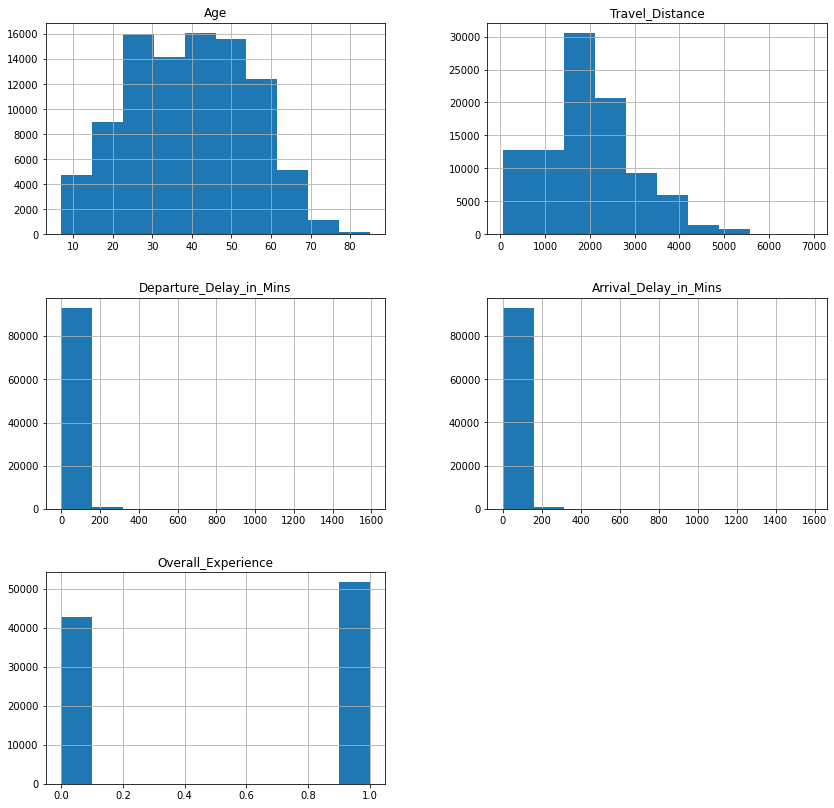

```python
df_train[num_cols].hist(figsize = (14,14))
plt.show()
```

```
Age
Skew : -0.0
```

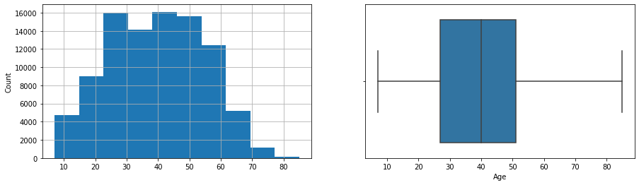

```
Travel_Distance
Skew : 0.47
```

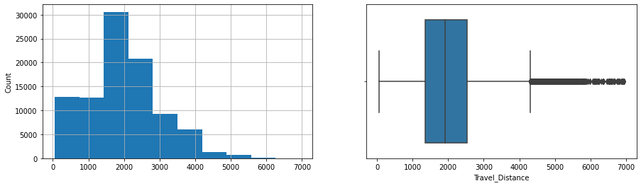

```
Departure_Delay_in_Mins
Skew : 7.16
```

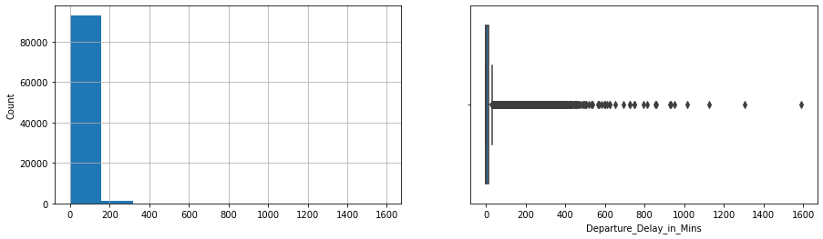

```
Arrival_Delay_in_Mins
Skew : 6.99
```

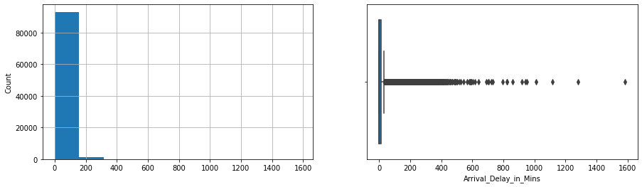

```
Overall_Experience
Skew : -0.19
```

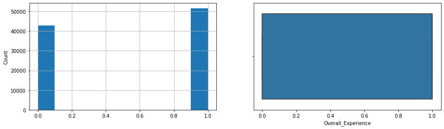

```python
for col in num_cols:
    print(col)
    print('Skew :',round(df_train[col].skew(),2))
    plt.figure(figsize=(15,4))
    plt.subplot(1,2,1)
    df_train[col].hist()
    plt.ylabel('Count')
    plt.subplot(1,2,2)
    sns.boxplot(x=col, data = df_train)
    plt.show()
```

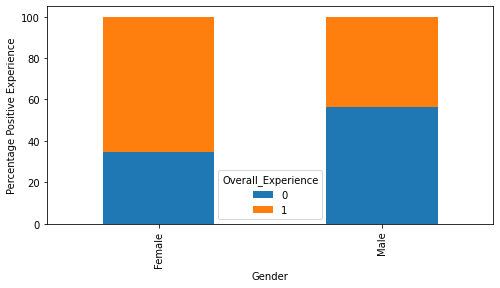

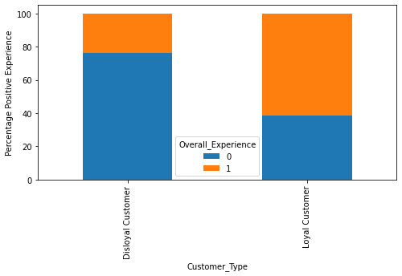

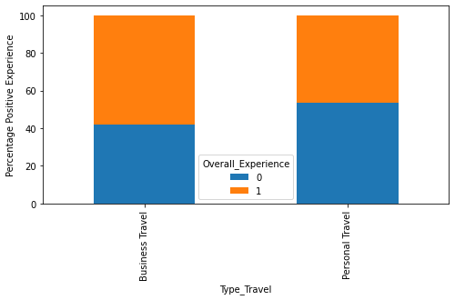

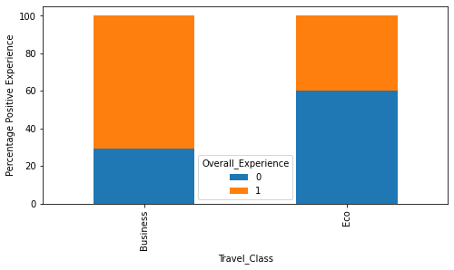

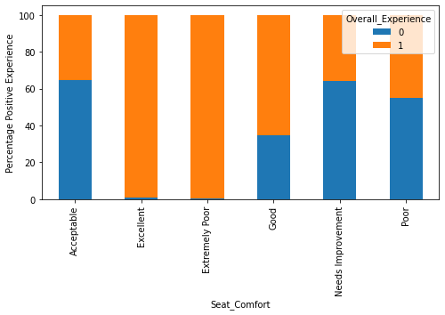

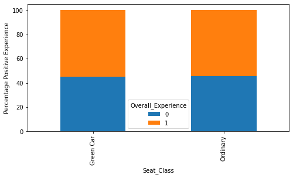

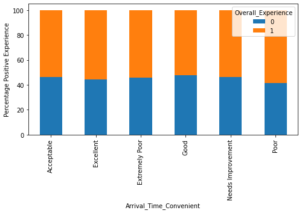

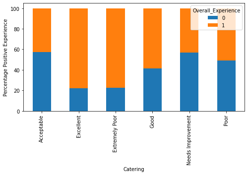

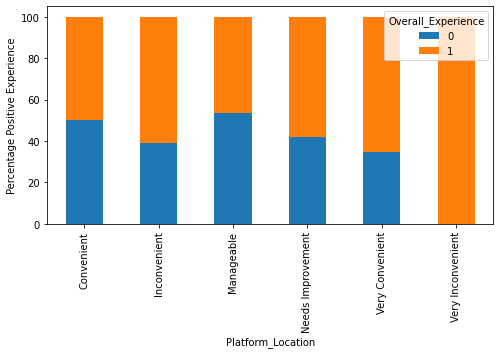

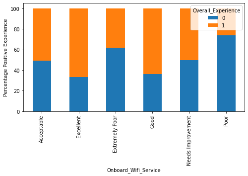

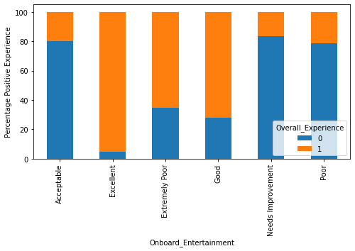

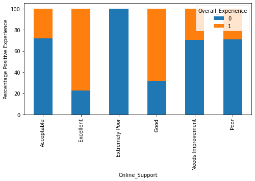

[7 more figures not shown]

```python
for i in cat_cols:
    if i != 'Overall_Experience':
        (pd.crosstab(df_train[i], df_train['Overall_Experience'], normalize = 'index')*100).plot(kind = 'bar', figsize = (8, 4), stacked = True)
        plt.ylabel('Percentage Positive Experience')
```

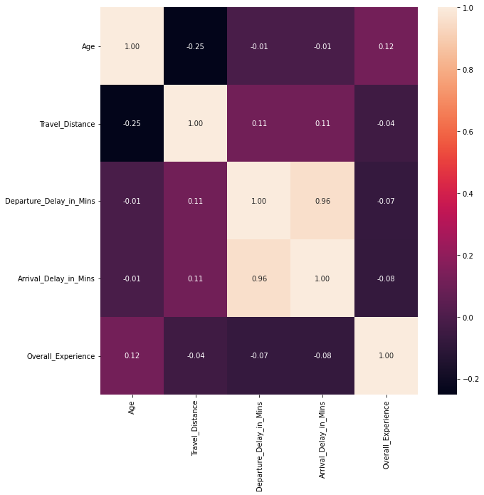

```python
plt.figure(figsize = (10,10))
sns.heatmap(df_train.corr(), annot= True, fmt = '0.2f')
plt.show()
```

### Treating Missing Values

```python
cat_cols = ['Gender','Travel_Class', 'Seat_Comfort',
            'Seat_Class','Platform_Location',
            'Onboard_Wifi_Service', 'Onboard_Entertainment', 'Online_Support', 'Ease_of_Online_Booking',
            'Legroom', 'Baggage_Handling', 'CheckIn_Service', 'Cleanliness', 'Online_Boarding']
```

```python
for column in df_train[cat_cols]:
  df_train[column].fillna(value = df_train[column].mode()[0], inplace = True)
```

```python
df_train.isnull().sum()
```

```
Gender                        0
Customer_Type              8951
Age                           0
Type_Travel                9226
Travel_Class                  0
Travel_Distance               0
Departure_Delay_in_Mins       0
Arrival_Delay_in_Mins         0
Overall_Experience            0
Seat_Comfort                  0
Seat_Class                    0
Arrival_Time_Convenient    8930
Catering                   8741
Platform_Location             0
Onboard_Wifi_Service          0
Onboard_Entertainment         0
Online_Support                0
Ease_of_Online_Booking        0
Onboard_Service            7601
Legroom                       0
Baggage_Handling              0
CheckIn_Service               0
Cleanliness                   0
Online_Boarding               0
dtype: int64
```

```python
# Printing number of count of each unique value in each column
for column in cat_cols:
    print("For column:", column, " there are: ",  df_train[column].nunique(), "unique values.")
    print (df_train[column].value_counts(normalize=True)*100)
    print("-" * 50)
```

```
For column: Gender  there are:  2 unique values.
Female    50.744339
Male      49.255661
Name: Gender, dtype: float64
--------------------------------------------------
For column: Travel_Class  there are:  2 unique values.
Eco         52.280698
Business    47.719302
Name: Travel_Class, dtype: float64
--------------------------------------------------
For column: Seat_Comfort  there are:  6 unique values.
Acceptable           22.482756
Needs Improvement    22.193496
Good                 21.821592
Poor                 16.089384
Excellent            13.743523
Extremely Poor        3.669248
Name: Seat_Comfort, dtype: float64
--------------------------------------------------
For column: Seat_Class  there are:  2 unique values.
Green Car    50.260121
Ordinary     49.739879
Name: Seat_Class, dtype: float64
--------------------------------------------------
For column: Platform_Location  there are:  6 unique values.
Manageable           25.644476
Convenient           23.217029
Needs Improvement    18.894034
Inconvenient         17.428665
Very Convenient      14.813677
Very Inconvenient     0.002119
Name: Platform_Location, dtype: float64
--------------------------------------------------
For column: Onboard_Wifi_Service  there are:  6 unique values.
Good                 24.226788
Excellent            22.216807
Acceptable           21.316183
Needs Improvement    20.763093
Poor                 11.380710
Extremely Poor        0.096420
```

[output cut: 58 more lines]

```
Acceptable           18.488223
Needs Improvement    10.390023
Poor                  5.968489
Extremely Poor        0.005298
Name: Cleanliness, dtype: float64
--------------------------------------------------
For column: Online_Boarding  there are:  6 unique values.
Good                 27.060045
Acceptable           23.813560
Excellent            23.036904
Needs Improvement    14.252111
Poor                 11.824664
Extremely Poor        0.012715
Name: Online_Boarding, dtype: float64
--------------------------------------------------
```

```python
cols_with_missing = ['Customer_Type', 'Type_Travel', 'Arrival_Time_Convenient', 'Catering', 'Onboard_Service']
```

```python
out = df_train["Customer_Type"].loc[df_train["Customer_Type"].isna()].index.tolist()
```

```python
len(out)
```

```
8951
```

```python
customer_type = df_train[cols_with_missing[0]].value_counts(normalize=True)
customer_type
```

```
Loyal Customer       0.817332
Disloyal Customer    0.182668
Name: Customer_Type, dtype: float64
```

```python
cust_missing = df_train[cols_with_missing[0]].isnull().sum()
cust_missing
```

```
8951
```

```python
cust_missing = df_train[cols_with_missing[0]].isnull()
df_train.loc[cust_missing,'Customer_Type'] = np.random.choice(customer_type.index, size=len(df_train[cust_missing]),p=customer_type.values)
df_train.isnull().sum()
```

```
Gender                        0
Customer_Type                 0
Age                           0
Type_Travel                9226
Travel_Class                  0
Travel_Distance               0
Departure_Delay_in_Mins       0
Arrival_Delay_in_Mins         0
Overall_Experience            0
Seat_Comfort                  0
Seat_Class                    0
Arrival_Time_Convenient    8930
Catering                   8741
Platform_Location             0
Onboard_Wifi_Service          0
Onboard_Entertainment         0
Online_Support                0
Ease_of_Online_Booking        0
Onboard_Service            7601
Legroom                       0
Baggage_Handling              0
CheckIn_Service               0
Cleanliness                   0
Online_Boarding               0
dtype: int64
```

```python
travel_type = df_train[cols_with_missing[1]].value_counts(normalize=True)
travel_type
```

```
Business Travel    0.688373
Personal Travel    0.311627
Name: Type_Travel, dtype: float64
```

```python
travel_type_missing = df_train[cols_with_missing[1]].isnull().sum()
travel_type_missing
```

```
9226
```

```python
travel_type_missing = df_train[cols_with_missing[1]].isnull()
df_train.loc[travel_type_missing,'Type_Travel'] = np.random.choice(travel_type.index, size=len(df_train[travel_type_missing]),p=travel_type.values)
df_train.isnull().sum()
```

```
Gender                        0
Customer_Type                 0
Age                           0
Type_Travel                   0
Travel_Class                  0
Travel_Distance               0
Departure_Delay_in_Mins       0
Arrival_Delay_in_Mins         0
Overall_Experience            0
Seat_Comfort                  0
Seat_Class                    0
Arrival_Time_Convenient    8930
Catering                   8741
Platform_Location             0
Onboard_Wifi_Service          0
Onboard_Entertainment         0
Online_Support                0
Ease_of_Online_Booking        0
Onboard_Service            7601
Legroom                       0
Baggage_Handling              0
CheckIn_Service               0
Cleanliness                   0
Online_Boarding               0
dtype: int64
```

```python
arrival_time_convenient = df_train[cols_with_missing[2]].value_counts(normalize=True)
arrival_time_convenient
```

```
Good                 0.229072
Excellent            0.206954
Acceptable           0.177615
Needs Improvement    0.175426
Poor                 0.160236
Extremely Poor       0.050697
Name: Arrival_Time_Convenient, dtype: float64
```

```python
arrival_time_convenient_missing = df_train[cols_with_missing[2]].isnull().sum()
arrival_time_convenient_missing
```

```
8930
```

```python
arrival_time_convenient_missing = df_train[cols_with_missing[2]].isnull()
df_train.loc[arrival_time_convenient_missing,'Arrival_Time_Convenient'] = np.random.choice(arrival_time_convenient.index, size=len(df_train[arrival_time_convenient_missing]),p=arrival_time_convenient.values)
df_train.isnull().sum()
```

```
Gender                        0
Customer_Type                 0
Age                           0
Type_Travel                   0
Travel_Class                  0
Travel_Distance               0
Departure_Delay_in_Mins       0
Arrival_Delay_in_Mins         0
Overall_Experience            0
Seat_Comfort                  0
Seat_Class                    0
Arrival_Time_Convenient       0
Catering                   8741
Platform_Location             0
Onboard_Wifi_Service          0
Onboard_Entertainment         0
Online_Support                0
Ease_of_Online_Booking        0
Onboard_Service            7601
Legroom                       0
Baggage_Handling              0
CheckIn_Service               0
Cleanliness                   0
Online_Boarding               0
dtype: int64
```

```python
catering = df_train[cols_with_missing[3]].value_counts(normalize=True)
catering
```

```
Acceptable           0.215652
Needs Improvement    0.209930
Good                 0.209825
Poor                 0.161821
Excellent            0.157115
Extremely Poor       0.045657
Name: Catering, dtype: float64
```

```python
catering_missing = df_train[cols_with_missing[3]].isnull().sum()
catering_missing
```

```
8741
```

```python
catering_missing = df_train[cols_with_missing[3]].isnull()
df_train.loc[catering_missing,'Catering'] = np.random.choice(catering.index, size=len(df_train[catering_missing]),p=catering.values)
df_train.isnull().sum()
```

```
Gender                        0
Customer_Type                 0
Age                           0
Type_Travel                   0
Travel_Class                  0
Travel_Distance               0
Departure_Delay_in_Mins       0
Arrival_Delay_in_Mins         0
Overall_Experience            0
Seat_Comfort                  0
Seat_Class                    0
Arrival_Time_Convenient       0
Catering                      0
Platform_Location             0
Onboard_Wifi_Service          0
Onboard_Entertainment         0
Online_Support                0
Ease_of_Online_Booking        0
Onboard_Service            7601
Legroom                       0
Baggage_Handling              0
CheckIn_Service               0
Cleanliness                   0
Online_Boarding               0
dtype: int64
```

```python
onboard_service = df_train[cols_with_missing[4]].value_counts(normalize=True)
onboard_service
```

```
Good                 0.314193
Excellent            0.245131
Acceptable           0.208244
Needs Improvement    0.131254
Poor                 0.101132
Extremely Poor       0.000046
Name: Onboard_Service, dtype: float64
```

```python
onboard_service_missing = df_train[cols_with_missing[4]].isnull()
df_train.loc[onboard_service_missing,'Onboard_Service'] = np.random.choice(onboard_service.index, size=len(df_train[onboard_service_missing]),p=onboard_service.values)
df_train.isnull().sum()
```

```
Gender                     0
Customer_Type              0
Age                        0
Type_Travel                0
Travel_Class               0
Travel_Distance            0
Departure_Delay_in_Mins    0
Arrival_Delay_in_Mins      0
Overall_Experience         0
Seat_Comfort               0
Seat_Class                 0
Arrival_Time_Convenient    0
Catering                   0
Platform_Location          0
Onboard_Wifi_Service       0
Onboard_Entertainment      0
Online_Support             0
Ease_of_Online_Booking     0
Onboard_Service            0
Legroom                    0
Baggage_Handling           0
CheckIn_Service            0
Cleanliness                0
Online_Boarding            0
dtype: int64
```

**Treating Missing Values for Test Data**

```python
df_test.isnull().sum()
```

```
Gender                       30
Customer_Type              3383
Age                           0
Type_Travel                3448
Travel_Class                  0
Travel_Distance               0
Departure_Delay_in_Mins       0
Arrival_Delay_in_Mins         0
Seat_Comfort                 22
Seat_Class                    0
Arrival_Time_Convenient    3325
Catering                   3357
Platform_Location            12
Onboard_Wifi_Service         12
Onboard_Entertainment         8
Online_Support               26
Ease_of_Online_Booking       18
Onboard_Service            2872
Legroom                      25
Baggage_Handling             40
CheckIn_Service              22
Cleanliness                   2
Online_Boarding               2
dtype: int64
```

```python
for column in df_test[cat_cols]:
  df_test[column].fillna(value = df_test[column].mode()[0], inplace = True)
```

```python
customer_type = df_test[cols_with_missing[0]].value_counts(normalize=True)
cust_missing = df_test[cols_with_missing[0]].isnull()
df_test.loc[cust_missing,'Customer_Type'] = np.random.choice(customer_type.index, size=len(df_test[cust_missing]),p=customer_type.values)
df_test.isnull().sum()
```

```
Gender                        0
Customer_Type                 0
Age                           0
Type_Travel                3448
Travel_Class                  0
Travel_Distance               0
Departure_Delay_in_Mins       0
Arrival_Delay_in_Mins         0
Seat_Comfort                  0
Seat_Class                    0
Arrival_Time_Convenient    3325
Catering                   3357
Platform_Location             0
Onboard_Wifi_Service          0
Onboard_Entertainment         0
Online_Support                0
Ease_of_Online_Booking        0
Onboard_Service            2872
Legroom                       0
Baggage_Handling              0
CheckIn_Service               0
Cleanliness                   0
Online_Boarding               0
dtype: int64
```

```python
travel_type = df_test[cols_with_missing[1]].value_counts(normalize=True)
travel_type_missing = df_test[cols_with_missing[1]].isnull()
df_test.loc[travel_type_missing,'Type_Travel'] = np.random.choice(travel_type.index, size=len(df_test[travel_type_missing]),p=travel_type.values)
df_test.isnull().sum()
```

```
Gender                        0
Customer_Type                 0
Age                           0
Type_Travel                   0
Travel_Class                  0
Travel_Distance               0
Departure_Delay_in_Mins       0
Arrival_Delay_in_Mins         0
Seat_Comfort                  0
Seat_Class                    0
Arrival_Time_Convenient    3325
Catering                   3357
Platform_Location             0
Onboard_Wifi_Service          0
Onboard_Entertainment         0
Online_Support                0
Ease_of_Online_Booking        0
Onboard_Service            2872
Legroom                       0
Baggage_Handling              0
CheckIn_Service               0
Cleanliness                   0
Online_Boarding               0
dtype: int64
```

```python
arrival_time_convenient = df_test[cols_with_missing[2]].value_counts(normalize=True)
arrival_time_convenient_missing = df_test[cols_with_missing[2]].isnull()
df_test.loc[arrival_time_convenient_missing,'Arrival_Time_Convenient'] = np.random.choice(arrival_time_convenient.index, size=len(df_test[arrival_time_convenient_missing]),p=arrival_time_convenient.values)
df_test.isnull().sum()
```

```
Gender                        0
Customer_Type                 0
Age                           0
Type_Travel                   0
Travel_Class                  0
Travel_Distance               0
Departure_Delay_in_Mins       0
Arrival_Delay_in_Mins         0
Seat_Comfort                  0
Seat_Class                    0
Arrival_Time_Convenient       0
Catering                   3357
Platform_Location             0
Onboard_Wifi_Service          0
Onboard_Entertainment         0
Online_Support                0
Ease_of_Online_Booking        0
Onboard_Service            2872
Legroom                       0
Baggage_Handling              0
CheckIn_Service               0
Cleanliness                   0
Online_Boarding               0
dtype: int64
```

```python
catering = df_train[cols_with_missing[3]].value_counts(normalize=True)
catering_missing = df_test[cols_with_missing[3]].isnull()
df_test.loc[catering_missing,'Catering'] = np.random.choice(catering.index, size=len(df_test[catering_missing]),p=catering.values)
df_test.isnull().sum()
```

```
Gender                        0
Customer_Type                 0
Age                           0
Type_Travel                   0
Travel_Class                  0
Travel_Distance               0
Departure_Delay_in_Mins       0
Arrival_Delay_in_Mins         0
Seat_Comfort                  0
Seat_Class                    0
Arrival_Time_Convenient       0
Catering                      0
Platform_Location             0
Onboard_Wifi_Service          0
Onboard_Entertainment         0
Online_Support                0
Ease_of_Online_Booking        0
Onboard_Service            2872
Legroom                       0
Baggage_Handling              0
CheckIn_Service               0
Cleanliness                   0
Online_Boarding               0
dtype: int64
```

```python
onboard_service = df_test[cols_with_missing[4]].value_counts(normalize=True)
onboard_service_missing = df_test[cols_with_missing[4]].isnull()
df_test.loc[onboard_service_missing,'Onboard_Service'] = np.random.choice(onboard_service.index, size=len(df_test[onboard_service_missing]),p=onboard_service.values)
df_test.isnull().sum()
```

```
Gender                     0
Customer_Type              0
Age                        0
Type_Travel                0
Travel_Class               0
Travel_Distance            0
Departure_Delay_in_Mins    0
Arrival_Delay_in_Mins      0
Seat_Comfort               0
Seat_Class                 0
Arrival_Time_Convenient    0
Catering                   0
Platform_Location          0
Onboard_Wifi_Service       0
Onboard_Entertainment      0
Online_Support             0
Ease_of_Online_Booking     0
Onboard_Service            0
Legroom                    0
Baggage_Handling           0
CheckIn_Service            0
Cleanliness                0
Online_Boarding            0
dtype: int64
```

```python
df_test_copy = df_test.copy()
```

# **Model Building**

1. Data preparation.
2. Partition the data into a train and test set.
3. Build a model on the train data.
4. Tune the model if required.
5. Test the data on the test set.

**Encoding Categorical Data for TRAIN**

```python
df_train = df_train.replace(['Female', 'Male'], [0,1])
df_train = df_train.replace(['Disloyal Customer', 'Loyal Customer'], [0,1])
df_train = df_train.replace(['Personal Travel','Business Travel'], [0,1])
df_train = df_train.replace(['Eco', 'Business'], [0,1])
df_train = df_train.replace(['Extremely Poor', 'Poor', 'Needs Improvement', 'Acceptable', 'Good', 'Excellent'], [0,1,2,3,4,5])
df_train = df_train.replace(['Green Car', 'Ordinary'], [0,1])
df_train = df_train.replace(['Very Inconvenient', 'Inconvenient', 'Needs Improvement', 'Manageable', 'Convenient', 'Very Convenient'], [0,1,2,3,4,5])
```

**Encoding Categorical Data for TEST**

```python
df_test = df_test.replace(['Female', 'Male'], [0,1])
df_test = df_test.replace(['Disloyal Customer', 'Loyal Customer'], [0,1])
df_test = df_test.replace(['Personal Travel','Business Travel'], [0,1])
df_test = df_test.replace(['Eco', 'Business'], [0,1])
df_test = df_test.replace(['Extremely Poor', 'Poor', 'Needs Improvement', 'Acceptable', 'Good', 'Excellent'], [0,1,2,3,4,5])
df_test = df_test.replace(['Green Car', 'Ordinary'], [0,1])
df_test = df_test.replace(['Very Inconvenient', 'Inconvenient', 'Needs Improvement', 'Manageable', 'Convenient', 'Very Convenient'], [0,1,2,3,4,5])
```

```python
# Creating metric function

def metrics_score(actual, predicted):

    print(classification_report(actual, predicted))

    cm = confusion_matrix(actual, predicted)

    plt.figure(figsize = (8, 5))

    sns.heatmap(cm, annot = True, fmt = '.2f', xticklabels = ['Positive Experience', 'Negative Experience'], yticklabels = ['Positive Experience', 'Negative Experience'])
    plt.ylabel('Actual')

    plt.xlabel('Predicted')

    plt.show()
```

```python
def model_performance_classification(model, predictors, target):
    """
    Function to compute different metrics to check classification model performance

    model: classifier

    predictors: independent variables

    target: dependent variable
    """

    # Predicting using the independent variables
    pred = model.predict(predictors)

    recall = recall_score(target, pred,average = 'macro')                 # To compute recall

    precision = precision_score(target, pred, average = 'macro')              # To compute precision

    acc = accuracy_score(target, pred)                                 # To compute accuracy score


    # Creating a dataframe of metrics

    df_perf = pd.DataFrame(
        {
            "Precision":  precision,
            "Recall":  recall,
            "Accuracy": acc,
        },

        index = [0],
    )

    return df_perf
```

### **Building a Decision Tree Model**

- We will build our model using the **DecisionTreeClassifier function.**
- If the frequency of class A is 17% and the frequency of class B is 83%, then class B will become the dominant class and **the decision tree will become biased toward the dominant class.**
- **class_weight is a hyperparameter** for the decision tree classifier, and in this case, we can pass a dictionary {0:0.17, 1:0.83} to the model to specify the weight of each class and the decision tree will give more weightage to class 1.

```python
overall_experience = df_train['Overall_Experience'].value_counts(normalize=True)
overall_experience
```

```
1    0.546658
0    0.453342
Name: Overall_Experience, dtype: float64
```

**Split the Data**

```python
X = df_train.drop('Overall_Experience', axis = 1)
Y = df_train['Overall_Experience']
```

```python
x_train, x_test, y_train, y_test = train_test_split(X, Y, test_size = 0.3, random_state = 1, stratify = Y)
```

```python
# Building decision tree model
dt = DecisionTreeClassifier(class_weight = {0: 0.45, 1: 0.55}, random_state = 1)
```

```python
dt.fit(x_train, y_train)
```

```
DecisionTreeClassifier(class_weight={0: 0.45, 1: 0.55}, random_state=1)
```

```
              precision    recall  f1-score   support

           0       1.00      1.00      1.00     29950
           1       1.00      1.00      1.00     36115

    accuracy                           1.00     66065
   macro avg       1.00      1.00      1.00     66065
weighted avg       1.00      1.00      1.00     66065
```

[figure not shown]

```python
# Checking performance on the training dataset
y_train_pred_dt = dt.predict(x_train)

metrics_score(y_train, y_train_pred_dt)
```

```
              precision    recall  f1-score   support

           0       0.92      0.91      0.91     12836
           1       0.93      0.93      0.93     15478

    accuracy                           0.92     28314
   macro avg       0.92      0.92      0.92     28314
weighted avg       0.92      0.92      0.92     28314
```

[figure not shown]

```python
# Checking performance on the test dataset
y_test_pred_dt = dt.predict(x_test)

metrics_score(y_test, y_test_pred_dt)
```

```python
dtree_test = model_performance_classification(dt,x_test,y_test)
dtree_test
```

|  | Precision | Recall | Accuracy |
| --- | --- | --- | --- |
| 0 | 0.920539 | 0.919977 | 0.920993 |

### Random Forest

```python
# Fitting the Random Forest classifier on the training data
rf_estimator = RandomForestClassifier(class_weight = {0: 0.45, 1: 0.55}, random_state = 1)

rf_estimator.fit(x_train, y_train)
```

```
RandomForestClassifier(class_weight={0: 0.45, 1: 0.55}, random_state=1)
```

```
              precision    recall  f1-score   support

           0       1.00      1.00      1.00     29950
           1       1.00      1.00      1.00     36115

    accuracy                           1.00     66065
   macro avg       1.00      1.00      1.00     66065
weighted avg       1.00      1.00      1.00     66065
```

[figure not shown]

```python
# Checking performance on the training data
y_pred_train_rf = rf_estimator.predict(x_train)

metrics_score(y_train, y_pred_train_rf)
```

```
              precision    recall  f1-score   support

           0       0.94      0.95      0.94     12836
           1       0.96      0.95      0.95     15478

    accuracy                           0.95     28314
   macro avg       0.95      0.95      0.95     28314
weighted avg       0.95      0.95      0.95     28314
```

[figure not shown]

```python
# Checking performance on the testing data
y_pred_test_rf = rf_estimator.predict(x_test)

metrics_score(y_test, y_pred_test_rf)
```

```python
rf_estimator_test = model_performance_classification(rf_estimator,x_test,y_test)
rf_estimator_test
```

|  | Precision | Recall | Accuracy |
| --- | --- | --- | --- |
| 0 | 0.946153 | 0.946971 | 0.946952 |

```python
rf_estimator_tuned = RandomForestClassifier(class_weight = {0: 0.45, 1: 0.55}, random_state = 1)

# Grid of parameters to choose from
params_rf = {
        "n_estimators": [100, 250, 500],
        "min_samples_leaf": np.arange(1, 4, 1),
        "max_features": [0.7, 0.9, 'auto'],
}


# Type of scoring used to compare parameter combinations - recall score for class 1
scorer = metrics.make_scorer(recall_score, pos_label = 1)

# Run the grid search
grid_obj = GridSearchCV(rf_estimator_tuned, params_rf, scoring = scorer, cv = 5)

grid_obj = grid_obj.fit(x_train, y_train)

# Set the classifier to the best combination of parameters
rf_estimator_tuned = grid_obj.best_estimator_
```

```python
y_test = np.asarray(y_test)
misclassified = np.where(y_test != rf_estimator.predict(x_test))
misclassified
```

```
(array([   42,    64,    67, ..., 28279, 28282, 28300]),)
```

### XGBoost

```python
# Installing the xgboost library using the 'pip' command.
!pip install xgboost
```

```python
# Importing the AdaBoostClassifier and GradientBoostingClassifier [Boosting]
from sklearn.ensemble import AdaBoostClassifier, GradientBoostingClassifier

# Importing the XGBClassifier from the xgboost library
from xgboost import XGBClassifier
```

```python
# Adaboost Classifier
adaboost_model = AdaBoostClassifier(random_state = 1)

# Fitting the model
adaboost_model.fit(x_train, y_train)

# Model Performance on the test data
adaboost_model_perf_test = model_performance_classification(adaboost_model,x_test,y_test)
adaboost_model_perf_test
```

|  | Precision | Recall | Accuracy |
| --- | --- | --- | --- |
| 0 | 0.894656 | 0.894729 | 0.895599 |

```python
# Gradient Boost Classifier
gbc = GradientBoostingClassifier(random_state = 1)

# Fitting the model
gbc.fit(x_train, y_train)

# Model Performance on the test data
gbc_perf_test = model_performance_classification(gbc, x_test, y_test)

gbc_perf_test
```

|  | Precision | Recall | Accuracy |
| --- | --- | --- | --- |
| 0 | 0.91988 | 0.91952 | 0.920428 |

```python
# XGBoost Classifier
xgb = XGBClassifier(random_state = 1, eval_metric = 'logloss')

# Fitting the model
xgb.fit(x_train,y_train)

# Model Performance on the test data
xgb_perf_test = model_performance_classification(xgb,x_test,y_test)

xgb_perf_test
```

|  | Precision | Recall | Accuracy |
| --- | --- | --- | --- |
| 0 | 0.916046 | 0.916079 | 0.91679 |

```python
models_test_comp_df = pd.concat(

    [
    dtree_test.T,rf_estimator_test.T, adaboost_model_perf_test.T,
    gbc_perf_test.T, xgb_perf_test.T
    ],

    axis = 1,
)

models_test_comp_df.columns = [
    "Decision Tree classifier",
    "Random Forest classifier",
    "Adaboost classifier",
    "Gradientboost classifier",
    "XGBoost classifier"
]

print("Test performance comparison:")
```

```
Test performance comparison:
```

```python
models_test_comp_df
```

[output not shown]

Of all the models tested, the Random Forest Classifier provided the highest results with regards to precision, accuracy, and recall.

```python
df_test.shape
```

```
(35602, 23)
```

```python
x_test = df_test
```

```python
x_test
```

[output not shown]

35602 rows × 23 columns

```python
model = rf_estimator
```

```python
prediction = model.predict(x_test)
```

```python
prediction.shape
```

```
(35602,)
```

```python
df_final = pd.DataFrame(prediction)
```

```python
df_final['ID'] = df_test.index
```

```python
df_final['Overall_Experience'] = prediction
```

```python
df_final.set_index('ID', inplace = True)
```

```python
df_final.drop(0, axis = 1)
```

| ID | Overall_Experience |
| --- | --- |
| 99900001 | 1 |
| 99900002 | 1 |
| 99900003 | 1 |
| 99900004 | 0 |
| 99900005 | 1 |
| ... | ... |
| 99935598 | 0 |
| 99935599 | 1 |
| 99935600 | 0 |
| 99935601 | 1 |
| 99935602 | 0 |

35602 rows × 1 columns

```python
df_final.drop(0, axis = 1, inplace = True)
```

```python
df_final
```

| ID | Overall_Experience |
| --- | --- |
| 99900001 | 1 |
| 99900002 | 1 |
| 99900003 | 1 |
| 99900004 | 0 |
| 99900005 | 1 |
| ... | ... |
| 99935598 | 0 |
| 99935599 | 1 |
| 99935600 | 0 |
| 99935601 | 1 |
| 99935602 | 0 |

35602 rows × 1 columns

```python
df_final.to_csv('/content/drive/MyDrive/Colab Notebooks/GL Hackathon/hackathon_prediction.csv', index = True)
```